# Alpine Vegetation - LTEM - EcoDomain Comparison

Published

2023-02-01

# 1 To do

- change log(PERCENT_COvER) to logit() scale
- set q in the header for diversity

# 2 Summary of Alpine Vegetation LTEM protocol

## 2.1 Basic protocol

As taken from the protocol document:

> “Permanent transects are established from just below present treeline to just above the transition from vegetation to rock (or ridgeline, whichever comes first). A 50cm X 50cm quadrat is sampled at regular intervals along the transect.

> The % foliar cover by species is recorded in each quadrat.”

The data collected under this protocol at each survey consists of the.

- Species. The species of vegetation in the plot.
- % foliar cover. What fraction of the plot is covered by this species.

## 2.2 Database structure

The relevant fields in the database are

- *Transect*. The transect measured.
- *Plot*. The plot within the transect.
- *Date*. The date the data was collected. The Year is extracted from this date.
- *Species*. What species were seen
- *Percent Cover*. The percent cover of each species in the plot.

The longitude and latitude are used to find the EcoDomain of each study area.

# 3 Reading and checking the data

## 3.1 Extract all LTEM data

The database was queried for all observations from this protocol in the Province.

The following surveys and years of surveys were found.

```
Number of records in each study area x year combination
```

```
                      Year
STUDY_AREA_NAME_shrt   2013 2014 2015 2016 2017 2018 2019 2020 2021
  Babine Mountains Par    0    0    0    0  362    0    0    0    0
  Big White Mountain E    0    0    0    0  286    0    0    0    0
  Butler Ridge Provinc    0    0    0    0    0    0  200    0    0
  Callaghan Lake Provi    0    0    0    0    0    0   90    0    0
  Cathedral Provincial    0    0  293    0    0    0  220    0    0
  Clayton Falls Conser    0    0    0    0    0  191    0    0    0
  Duu Guusd Heritage S    0    0    0  109    0    0    0    0    0
  Garibaldi Provincial  266   87    0    0    0  202    0    0    0
  Golden Ears Provinci    0    0    0    0    0    0   84    0    0
  Haley Lake Ecologica    0    0    0    0    0   72    0    0    0
  Monarch Mountain/A X    0    0    0    0    0    0  135    0    0
  Mount Assiniboine Pr    0    0    0    0    0  417    0    0    0
  Mount Robson Provinc    0    0  364    0    0    0    0    0  652
  Nadina Mountain Prov    0  144    0    0    0  139    0    0    0
  Seven Sisters Provin    0    0  315    0    0    0  248    0    0
  Spatsizi Plateau Wil    0    0    0    0  289    0    0    0    0
  Stagleap Provincial     0   48    0    0    0    0    0    0    0
  Stone Mountain Provi    0    0    0  284    0    0    0    0  220
  Strathcona Provincia    0    0    0    0    0    0    0    0   70
  Wells Grey Provincia    0    0    0    0    0    0    0  182    0
```

It is not necessary that every STUDY_AREA be measured in every year and the number of measurements at each STUDY_AREA can vary within years and across years.

If STUDY_AREA is only measured in one year, it does not provide any information on the trends and can be dropped. Similary, STUDY_AREAS with only 2 years of data, provide no information on the uncertainty; they can be retained or dropped.

STUDY_AREAs dropped for insuffient data are:

Study areas dropped because of insufficient years of data

| Study Area | # years of data |
| --- | --- |
| Babine Mountains Park | 1 |
| Big White Mountain Ecological Reserve | 1 |
| Butler Ridge Provincial Park | 1 |
| Callaghan Lake Provincial Park | 1 |
| Clayton Falls Conservancy | 1 |
| Duu Guusd Heritage Site/Conservancy | 1 |
| Golden Ears Provincial Park | 1 |
| Haley Lake Ecological Reserve | 1 |
| Monarch Mountain/A Xeegi Deiyi Conservancy | 1 |
| Mount Assiniboine Provincial Park | 1 |
| Spatsizi Plateau Wilderness Provincial Park | 1 |
| Stagleap Provincial Park | 1 |
| Strathcona Provincial Park | 1 |
| Wells Grey Provincial Park | 1 |

## 3.2 Ecodomain of each study area

The Ecodomain of each study area was obtained by looking up the mean latitude/longitude of observations for each STUDY_AREA in the Ecoprovices provided in the *bcmaps* package. In some cases, no long/lat data was provided and these study areas will also be excluded.

```
Site missing long/lat data
```

```
  STUDY_AREA_NAME_shrt LONGITUDE_DD LATITUDE_DD
1 Cathedral Provincial           NA          NA
```

The classification of each STUDY_AREA into its EcoDomain is:

```
                      ECODOMAIN
STUDY_AREA_NAME_shrt   CoastMtn HumConHigh North
  Garibaldi Provincial        1          0     0
  Mount Robson Provinc        0          2     0
  Nadina Mountain Prov        0          1     0
  Seven Sisters Provin        1          0     0
  Stone Mountain Provi        0          0     1
```

```
# check if at least 2 eco domains at at least 4 study areas and at least 3 years x 2 ecodomains x 4 study area
```

**Mt Robson has two separate transects entered as two separate projects**

## 3.3 Checking species code

The species code should be the same across for all data values.. Note that in many years, a code of *NULL* was entered to indicate no vegetation of any species were detected. **This table shows the total detections for each species.year combination over all the transects in all STUDY_AREAs and EcoDomains - check that codes are sensible.**

```
                 Year
SPECIES_CODE      2013 2014 2015 2016 2018 2019 2021
  ABIELAS1           0    1    2    0    4    2    0
  ACHIMIL            0    0    4    0    0    0    4
  ACONDEL            0    0    1    0    0    1    0
  AGOSAUR2           0    0    0    0    0    0    2
  ANEMNAR3           0    0   11    0    0   10    0
  ANEMOCC            4    4    0    0    4    0    0
  ANEMPAR            0    0   10    6    0    0   26
  ANTEDEN            0    0    0    0    0    0    1
  ANTELAN            0    0    0    0    0    0   16
  ANTEMED            0    0    0    0    0    0   10
  ANTEMIC            0    2    0    0    2    0    0
  ANTENEG            0    0    2    0    0    1    0
  ANTENNARIA         0    0    0    2    0    0    0
  ANTEPAL            0    0   22    0    0    0    8
  ANTERAC            0    0    1    0    0    0    0
  ARCTRUR            0    0    0    4    0    0    4
  ARCTUVA            0    0    4    0    0    0    2
  ARNIANG1           0    1    0    0    0    0    0
  ARNIANG4           0    0    0    0    1    0    0
  ARNILAT            2    5    8    0   14    0    0
  ARNIMOL            0    0    0    0    0    0   10
  ARTENOR            0    0   26    0    0    0    0
  ARTENOR1           0    5    1    0    4    1   28
  ASCOMYCOTA         0    1    0    0   12    0    0
  ASTERACEAE         0    0    0    0    0    0    2
  ASTRAGALUS         0    0    0    7    0    0    0
  ASTRALP1           0    0    0    0    0    0   16
  AULAACU            0    0    0    0    0    0    1
  BARBLYC            0    0    1    0    0    2    0
  BETUNAN            0    0    0    1    0    0    2
  BISTBIS            0    0    0    0    0    1    0
  BISTVIV            0    0   11   17    0    2   45
  BRYOLAN            0    0    1    0    0    0    0
  BRYOPHYTA          2    7    0    5    1    0   26
  BRYOPSIDA          8    5   16    0   14    0    0
  CALAPUR4           0    0    0    0    0    0    2
  CALTLEP            3    0    0    0    0    0    0
  CALTLEP2           0    0    0    0    1    0    0
```

[output cut: 194 more lines]

```
  VACCOVL            0    0    0    0    2    0    0
  VACCULI            0    0    0    0    0    0    6
  VACCULI3           0    0    0    8    0    0    0
  VAHLATR            0    3    2    0   10    0    4
  VALESIT           27   15    0    0   18    0    2
  VERONICA           0    0    2    0    0    0    0
  VERONUT            0    0    0    0    1    0    0
  VEROWOR1           0    0    0    0    0    0   10
  VIOLACEAE          0    0    2    0    0    0    0
  VIOLADU1           0    0    0    0    0    0    4
  VIOLLAG            0    1    0    0    1    0    0
  VULPPIN            0    0    1    0    0    0    0
  WOODILV            0    0    2    0    0    0    0
  WOODSIA            0    0    0    0    0    0    1
  XANTHORIA          0    0    2    2    0    0    0
```

```
*** WARNING *** More than one species name found - OK if some are NULL
```

# 4 Multi-Site Analysis

We will now compare the trends in the EcoDomains.

This design has multiple transects that are repeatedly measured over time. Please refer to the Fitting Trends with Complex Study Designs document in the CommonFile directory for information on fitting trends with complex study designs.

All analyses were done using the R (R Core Team, 2023) analysis system. All plots are also saved as separate *png files for inclusion into other reports.

## 4.1 % cover

The data is first summarized to the plot level by summing the % cover, excluding non-plant coverage (e.g. rocks). Then the average total % cover for each transect is computed by averaging the total % cover over the plots within each transect. This makes an implicit assumption that all transects will have the same set of plots measured over time. If some plots have to be discarded (e.g. due to damage), the analysis will only be approximate, but unless the number of discarded plots is very large (e.g. more than a 1/3), the approximation should be adequate. This makes the unit of the analysis, the transect within each year.

### 4.1.1 Summarize to transect level

The data is first summarized to the transect-year level by finding the mean % cover per plot on a transect for each individual transect. This reduces the data to one measurement per transect per STUDY_AREA/year.

The first few records are:

```
                                      STUDY_AREA_NAME STUDY_AREA_NAME_shrt  ECODOMAIN Year TRANSECT PERCENT_COVER
1                           Garibaldi Provincial Park Garibaldi Provincial   CoastMtn 2013                0.00000
2                           Garibaldi Provincial Park Garibaldi Provincial   CoastMtn 2014       T3      73.90909
3                           Garibaldi Provincial Park Garibaldi Provincial   CoastMtn 2018               62.70000
4                           Garibaldi Provincial Park Garibaldi Provincial   CoastMtn 2018       T1     109.08750
5                           Garibaldi Provincial Park Garibaldi Provincial   CoastMtn 2018       T4      67.65000
6     Mount Robson Provincial Park Heather transect 2 Mount Robson Provinc HumConHigh 2015       T1       0.00000
7     Mount Robson Provincial Park Heather transect 2 Mount Robson Provinc HumConHigh 2015       T2       0.00000
8     Mount Robson Provincial Park Heather transect 2 Mount Robson Provinc HumConHigh 2021       T1      48.95455
9     Mount Robson Provincial Park Heather transect 2 Mount Robson Provinc HumConHigh 2021       T2      87.66000
10 Mount Robson Provincial Park, Xanthoria transect 1 Mount Robson Provinc HumConHigh 2015       T1       0.00000
11 Mount Robson Provincial Park, Xanthoria transect 1 Mount Robson Provinc HumConHigh 2015       T2       0.00000
12 Mount Robson Provincial Park, Xanthoria transect 1 Mount Robson Provinc HumConHigh 2021       T1      48.95455
13 Mount Robson Provincial Park, Xanthoria transect 1 Mount Robson Provinc HumConHigh 2021       T2      87.66000
14                    Nadina Mountain Provincial Park Nadina Mountain Prov HumConHigh 2014       T1       0.00000
15                    Nadina Mountain Provincial Park Nadina Mountain Prov HumConHigh 2014       T2       0.00000
16                    Nadina Mountain Provincial Park Nadina Mountain Prov HumConHigh 2018       T1      95.35000
17                    Nadina Mountain Provincial Park Nadina Mountain Prov HumConHigh 2018       T2      77.70000
18                      Seven Sisters Provincial Park Seven Sisters Provin   CoastMtn 2015       T1       0.00000
19                      Seven Sisters Provincial Park Seven Sisters Provin   CoastMtn 2015       T2       0.00000
20                      Seven Sisters Provincial Park Seven Sisters Provin   CoastMtn 2019       T1     166.87000
21                      Seven Sisters Provincial Park Seven Sisters Provin   CoastMtn 2019       T2     127.10000
22                     Stone Mountain Provincial Park Stone Mountain Provi      North 2016  T1South       0.00000
23                     Stone Mountain Provincial Park Stone Mountain Provi      North 2016  T2North       0.00000
24                     Stone Mountain Provincial Park Stone Mountain Provi      North 2021  T1South      70.00000
25                     Stone Mountain Provincial Park Stone Mountain Provi      North 2021  T2North      89.19000
```

```
  STUDY_AREA_NAME_shrt  ECODOMAIN Year TRANSECT PERCENT_COVER
1 Garibaldi Provincial   CoastMtn 2013                0.00000
2 Garibaldi Provincial   CoastMtn 2014       T3      73.90909
3 Garibaldi Provincial   CoastMtn 2018               62.70000
4 Garibaldi Provincial   CoastMtn 2018       T1     109.08750
5 Garibaldi Provincial   CoastMtn 2018       T4      67.65000
6 Mount Robson Provinc HumConHigh 2015       T1       0.00000
```

It is implicitly assumed that all transects are run on all days within a STUDY_AREA so every transect has the same number of days of measurement. If transects are changed over time, that is not a problem, but transects should not be introduced or removed part way through a year.

### 4.1.2 Preliminary plot

A summary plot of the mean percent cover in each year for each STUDY_AREA and an the trends over time is shown in Figure 1.

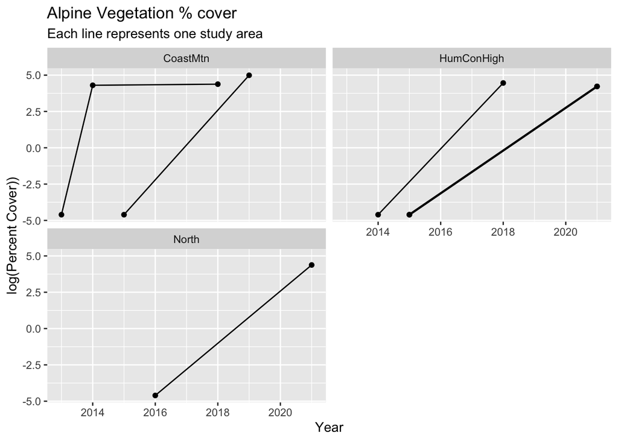

Figure 1: Summary plot of the data. The data is analyzed on the logarithmic scale.

### 4.1.3 Model

A non-parallel slope model is fit allowing for a different average slope (over the multiple STUDY_AREAs) in each EcoDomains (non-parallel slopes). Within each EcoDomain, each STUDY_AREA’s slope is allowed to vary randomly around the average slope for the EcoDomain. Within each STUDY_AREA, each transect is allowed to have a different intercept but common slope. Finally, we allow for year-specific factor within each EcoDomain.

The model, in a short-hand notation is:

$$log(PercentCover) \sim \mathit{EcoDomain} + \mathit{Year} + \mathit{EcoDomain}:\mathit{Year}+
\mathit{StudyArea} + \mathit{TransectF(R)} + \mathit{StudyArea}:\mathit{Year(R)} + \mathit{YearF:EcoDomain(R)}$$

where

- $log(PercentCover)$ is logarithm of the average percent cover per plot for that transect in that year.
- $\mathit{Year}$ term represents the average (over all EcoDomains) calendar year trend over time.
- $\mathit{EcoDomain}$ term represents a different intercept for each EcoDomain
- $\mathit{EcoDomain}:\mathit{Year}$ term represents the differential average slope for each EcoDomain
- $\mathit{StudyArea}:\mathit{Year(R)}$ term represents the random slopes within each EcoDomain for each study area
- $\mathit{TransectF(R)}$ represents the (random) transect effect;
- $\mathit{YearF:EcoDomain(R)}$ represents the (random) year-specific effects (process error), thare are allowed to vary across EcoDomains.

The The $\mathit{TransectF}$ term allows for the fact that transect-specific conditions may tend to affect the counts on this transect consistently over time. The $\mathit{YearF:EcoDomain}$ term represent the year-specific effects (process error) caused by environmental factors (e.g., a warmer than normal year may cause more plant growth).

The model was fit using the *lmerTest()* function (Kuznetsova, 2017) in *R* (R Core Team, 2023).

```
boundary (singular) fit: see help('isSingular')
```

```
Type III Analysis of Variance Table with Satterthwaite's method
                 Sum Sq Mean Sq NumDF  DenDF F value  Pr(>F)
Year            0.41685 0.41685     1 5.0013  9.6668 0.02657 *
ECODOMAINF      0.01673 0.00837     2 5.0018  0.1940 0.82957
Year:ECODOMAINF 0.00686 0.00343     2 5.0013  0.0795 0.92470
---
Signif. codes:  0 '***' 0.001 '**' 0.01 '*' 0.05 '.' 0.1 ' ' 1
```

```
Linear mixed model fit by REML. t-tests use Satterthwaite's method ['lmerModLmerTest']
Formula: log(PERCENT_COVER + 0.01) ~ Year + ECODOMAINF + Year:ECODOMAINF +      (1 | STUDY_AREA_NAMEF) + (Year - 1 | STUDY_AREA_NAME) + (1 |      TRANSECTF) + (1 | YearF:ECODOMAINF)
   Data: cover.transect

REML criterion at convergence: 44.2

Scaled residuals:
     Min       1Q   Median       3Q      Max
-1.40015 -0.46715 -0.00337  0.08351  1.64920

Random effects:
 Groups           Name        Variance  Std.Dev.
 TRANSECTF        (Intercept) 2.519e-04 0.01587
 YearF:ECODOMAINF (Intercept) 1.419e+01 3.76760
 STUDY_AREA_NAME  Year        0.000e+00 0.00000
 STUDY_AREA_NAMEF (Intercept) 0.000e+00 0.00000
 Residual                     4.312e-02 0.20766
Number of obs: 25, groups:  TRANSECTF, 14; YearF:ECODOMAINF, 11; STUDY_AREA_NAME, 6; STUDY_AREA_NAMEF, 6

Fixed effects:
                          Estimate Std. Error       df t value Pr(>|t|)
(Intercept)               -19.3643    11.6348   5.0085  -1.664    0.157
Year                        1.2815     0.7285   5.0065   1.759    0.139
ECODOMAINFHumConHigh       -5.8307    16.6075   5.0024  -0.351    0.740
ECODOMAINFNorth           -13.9606    23.0591   5.0029  -0.605    0.571
Year:ECODOMAINFHumConHigh   0.1921     1.0022   5.0016   0.192    0.856
Year:ECODOMAINFNorth        0.5135     1.2915   5.0027   0.398    0.707

Correlation of Fixed Effects:
              (Intr) Year   ECODOMAINFH ECODOMAINFN Y:ECODOMAINFH
Year          -0.989
ECODOMAINFH   -0.701  0.693
ECODOMAINFN   -0.505  0.499  0.353
Y:ECODOMAINFH  0.719 -0.727 -0.988      -0.363
Y:ECODOMAINFN  0.558 -0.564 -0.391      -0.988       0.410
optimizer (nloptwrap) convergence code: 0 (OK)
boundary (singular) fit: see help('isSingular')
```

### 4.1.4 Test for no difference in trends among EcoDomains

After the model is fit, the ANOVA tables summarizes the test for no differences in trends among the EcoDomains in Table 1.

Table 1: ANOVA table for testing for differences in trends among EcoDomains

| Source | NumDF | DenDF | p.value |
| --- | --- | --- | --- |
| Year | 1 | 5.0 | p = 0.027 |
| ECODOMAIN | 2 | 5.0 | p = 0.830 |
| Year:ECODOMAIN | 2 | 5.0 | p = 0.925 |

The *Year:ECODOMAIN* term tests the hypothesis that the slopes in all of the EcoDomains are equal. If the p-value is large, then there is no evidence that the slopes among the EcoDomains are different.

### 4.1.5 Estimated slopes

The estimated coefficients from *R* output above do not have a direct interpretation because of the way that *R* codes the design matrix for discrete variables such as the EcoDomain.These coefficients associated with each EcoDomain are the difference in the slopes between the slope for that particular EcoDomain and the reference EcoDomain (typically the EcoDomain that is “first” alphabetically).

The estimated slope for each EcoDomain are estimated using the *emmeans* package (Lenth, 2023) presented in Table 2.

Table 2: Estimated slope in each EcoDomain

| Eco Domain | Slope | SE | df | 95% LCL | 95% UCL | Grouping |
| --- | --- | --- | --- | --- | --- | --- |
| CoastMtn | 1.2815 | 0.7285 | 5.0 | -0.5905 | 3.1535 | 1 |
| HumConHigh | 1.4736 | 0.6882 | 5.0 | -0.2959 | 3.2431 | 1 |
| North | 1.7950 | 1.0664 | 5.0 | -0.9462 | 4.5362 | 1 |

Degrees-of-freedom method: satterthwaite  
Confidence level used: 0.95  
Note: contrasts are still on the 0.01(mu + 0.01) scale  
Degrees-of-freedom method: satterthwaite  
P value adjustment: tukey method for comparing a family of 3 estimates  
significance level used: alpha = 0.05  
NOTE: If two or more means share the same grouping symbol, then we cannot show them to be different. But we also did not show them to be the same.

The *Grouping* column indicates if there is evidence of a difference among the slopes across EcoDomains. EcoDomains that contain the same “digit” would indicate no evidence of a difference in the mean slopes among the EcoDomains. This is a summary of the overall p-value for parallelism found in the ANOVA table of p = 0.925. For more information on interpretting the *.group* variable, refer to https://schmidtpaul.github.io/DSFAIR/compactletterdisplay.html.

### 4.1.6 Mean slope over all EcoDomains

The average slope over all EcoDomains (giving each EcoDomain equal weight regardless of the number of study areas in the EcoDomain) shown in Table 3.

Table 3: Estimated mean slope over all EcoDomains

| Mean slope | Slope | SE | df | 95% LCL | 95% UCL | p.value |
| --- | --- | --- | --- | --- | --- | --- |
| overall | 1.5167 | 0.4878 | 5.0 | 0.2628 | 2.7706 | p = 0.027 |

Results are averaged over the levels of: ECODOMAINF  
Degrees-of-freedom method: satterthwaite  
Confidence level used: 0.95

The overall average slope over all EcoDomain is 1.517 (SE 0.488 with a p-value of p = 0.027. This is the same p-value from the ANOVA table for the *Year* term.

The estimated mean slope is interpreted in the same way as the slopes for each EcoDomain.

### 4.1.7 Summary plot

Figure 2 shows a summary plot, along with estimates of the slope, its standard error, and the p-value of the hypothesis of no trend in each EcoDomain.

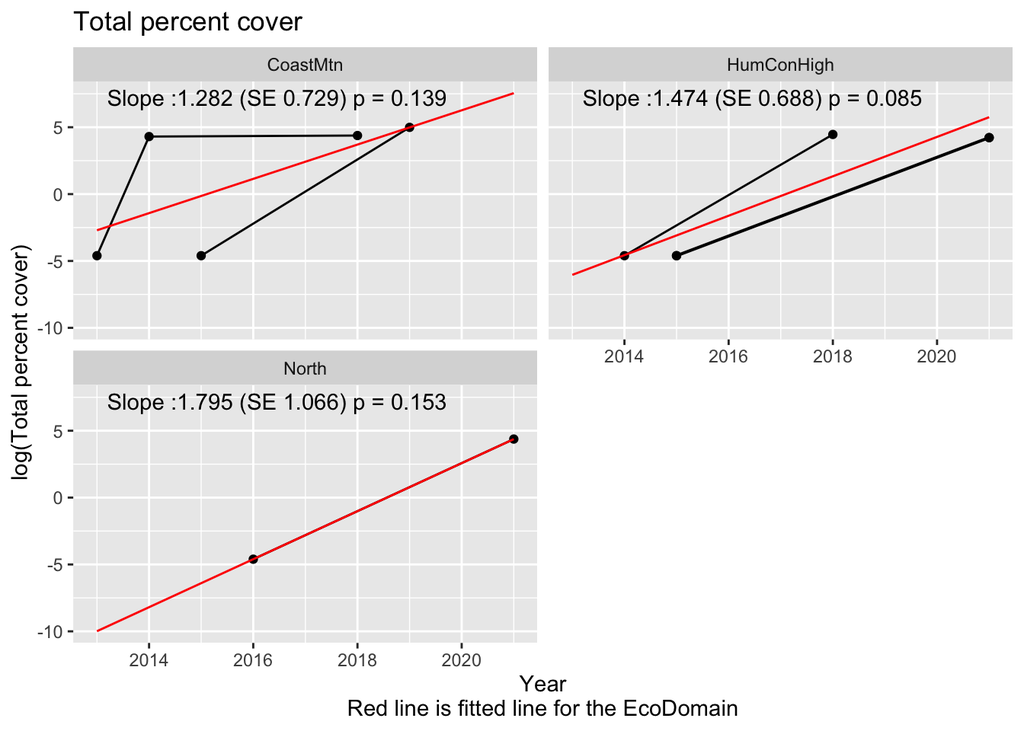

Figure 2: Summary plot of the trend in total percent cover.

### 4.1.8 Estimated variance component

The estimated variance components are shown in Table 4.

Table 4: Estimated variance components

| Component | Interaction | SD |
| --- | --- | --- |
| TRANSECT |  | 0.016 |
| YearF:ECODOMAIN |  | 3.768 |
| STUDY_AREA_NAME | Year | 0.000 |
| STUDY_AREA_NAME |  | 0.000 |
| Residual |  | 0.208 |

The *STUDY_AREA_NAME* and *STUDY_AREA_NAME:Year* represent the variation in the intercepts and slopes among study areas within an EcoDomain. The *TRANSECT* component represents the variation in intercepts among multiple transects within the same STUDY_AREA. The *YearF:ECODOMAIN* components represents the variation in the year specific factors (process error) within the EcoDomains. Finally the *Residual* component represents the left-over, unexplained variation in the data.

Notice in this case, that the variation in the slopes for each STUDY_AREA within the EcoDomains is very close to 0, i.e., the different study areas could all have similar slopes within the EcoDomain. If you examine the individual slopes in each study area (see the individual study area reports), the estimated standard error is quite large indicating the the slopes could be roughly the same across study areas (see Figure 3).

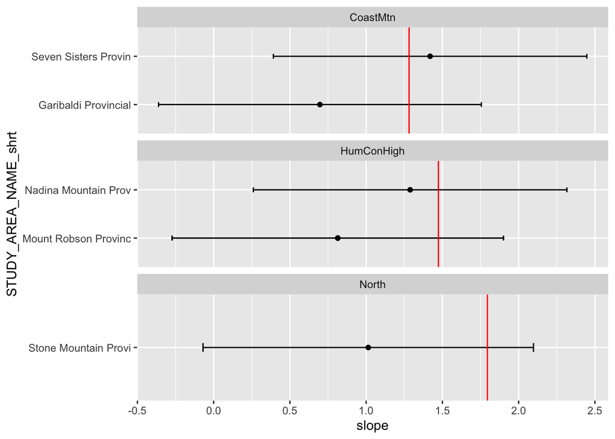

Figure 3: Comparing the individual slopes within each EcoRegion

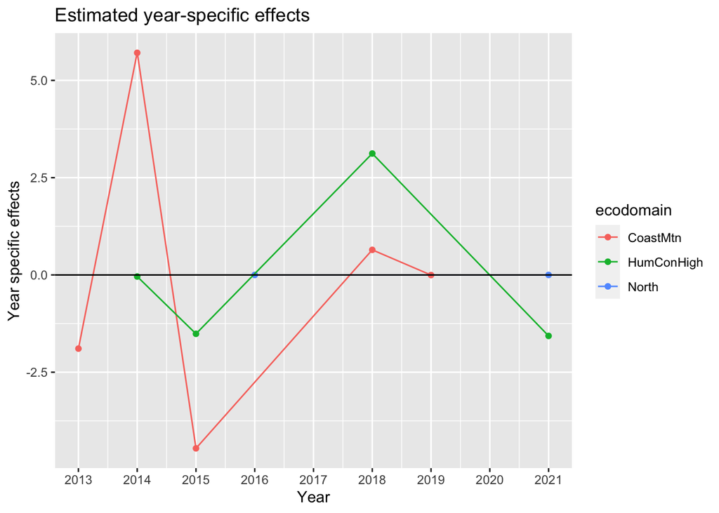

Figure 4: Plot of year specific effects

We see that the year-specific effects can vary across EcoDomains, e.g., the year-specific impact of weather can be different in the different EcoDomains. This is not surprising because B.C. is a large Province!

### 4.1.9 Residual plots

Residual plots are presented in Figure 5.

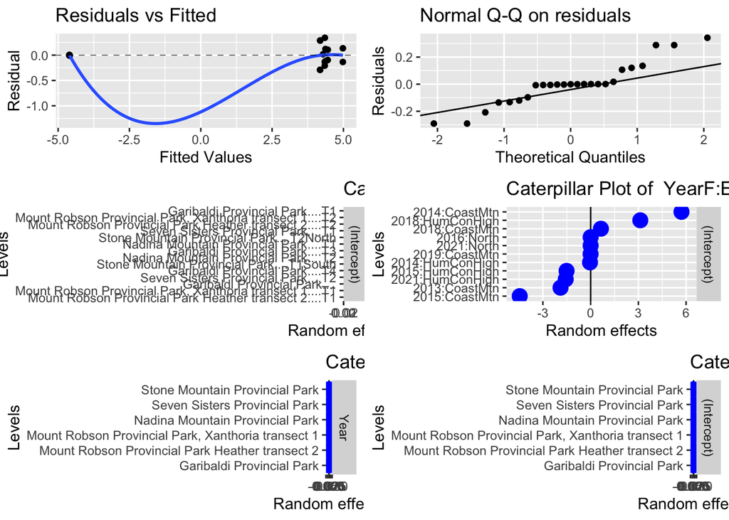

Figure 5: Model fit diagnostic plots from trend in mean transect counts

## 4.2 Species Richness

A similar analysis can be applied to the average species richness at the plot level as in the previous section. The data is first summarized to the plot level by counting the number of plant species, excluding non-plant richnessage (e.g. rocks). Some case is needed when plants are only identified to the Genus or Family level – these may have to be removed to avoid double counting. For example, in the test dataset, there were cases where the id was unknown and the plant was labeled “unknown #1”. This was not acceptable to the SPI database, so an identification was given to the level it was known which was sometimes as vague as *Poaceae* (family) or *Dicotyledoneae* (class). It is assumed that a plant was a different species than all the others that were known when it is labelled as “unknown2”

Then the average species richness (at the plot level) for each transect is computed by averaging the species richness over the plots within each transect. This makes an implicit assumption that all transects will have the same set of plots measured over time so that the transect mean richness has roughly the same precision in all transects. If some plots have to be discarded (e.g. due to damage), the analysis will only be approximate, but unless the number of discarded plots is very large (e.g. more than a 1/3), the approximation should be adequate. This makes the unit of the analysis, the transect within each year.

The first few records are:

```
  STUDY_AREA_NAME_shrt  ECODOMAIN Year TRANSECT richness
1 Garibaldi Provincial   CoastMtn 2013          1.000000
2 Garibaldi Provincial   CoastMtn 2014       T3 7.181818
3 Garibaldi Provincial   CoastMtn 2018          6.000000
4 Garibaldi Provincial   CoastMtn 2018       T1 8.000000
5 Garibaldi Provincial   CoastMtn 2018       T4 7.818182
6 Mount Robson Provinc HumConHigh 2015       T1 1.000000
```

It is implicitly assumed that all transects are run on all days within a STUDY_AREA so every transect has the same number of days of measurement. If transects are changed over time, that is not a problem, but transects should not be introduced or removed part way through a year.

### 4.2.1 Preliminary plot

A summary plot of the mean richness in each year for each STUDY_AREA and an the trends over time is shown in Figure 6.

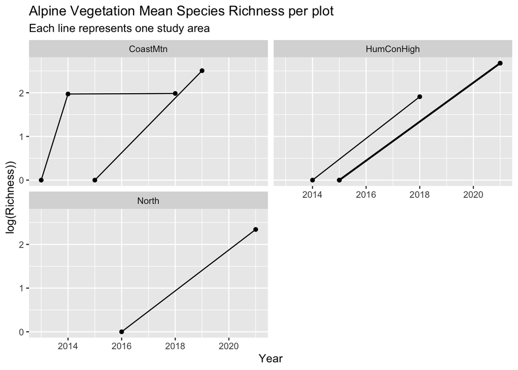

Figure 6: Summary plot of the data. The data is analyzed on the logarithmic scale.

### 4.2.2 Model

A non-parallel slope model is fit allowing for a different average slope (over the multiple STUDY_AREAs) in each EcoDomains (non-parallel slopes). Within each EcoDomain, each STUDY_AREA’s slope is allowed to vary randomly around the average slope for the EcoDomain. Within each STUDY_AREA, each transect is allowed to have a different intercept but common slope. Finally, we allow for year-specific factor within each EcoDomain.

The model, in a short-hand notation is:

$$log(Richness) \sim \mathit{EcoDomain} + \mathit{Year} + \mathit{EcoDomain}:\mathit{Year}+
\mathit{StudyArea} + \mathit{TransectF(R)} + \mathit{StudyArea}:\mathit{Year(R)} + \mathit{YearF:EcoDomain(R)}$$

where

- $log(Richness)$ is logarithm of the average percent richness per plot for that transect in that year.
- $\mathit{Year}$ term represents the average (over all EcoDomains) calendar year trend over time.
- $\mathit{EcoDomain}$ term represents a different intercept for each EcoDomain
- $\mathit{EcoDomain}:\mathit{Year}$ term represents the differential average slope for each EcoDomain
- $\mathit{StudyArea}:\mathit{Year(R)}$ term represents the random slopes within each EcoDomain for each study area
- $\mathit{TransectF(R)}$ represents the (random) transect effect;
- $\mathit{YearF:EcoDomain(R)}$ represents the (random) year-specific effects (process error), thare are allowed to vary across EcoDomains.

The The $\mathit{TransectF}$ term allows for the fact that transect-specific conditions may tend to affect the counts on this transect consistently over time. The $\mathit{YearF:EcoDomain}$ term represent the year-specific effects (process error) caused by environmental factors (e.g., a warmer than normal year may elict greater plant growth).

Model fit on the logarithmic scale assume that effects are multiplicative over time, so that the when the actual fit is done on the logarithmic scale, the trends are linear. For example, a trend may assume that there is constant 5% change over time rather than a fixed 1-unit change per year. Some caution is needed if any of the values are 0 as log(0) is not defined. In these cases, a small constant (typically ½ of the smallest positive value in the dataset) is added to all values before the analysis proceeds.

The model was fit using the *lmerTest()* function (Kuznetsova, 2017) in *R* (R Core Team, 2023).

```
boundary (singular) fit: see help('isSingular')
```

```
Type III Analysis of Variance Table with Satterthwaite's method
                  Sum Sq  Mean Sq NumDF  DenDF F value  Pr(>F)
Year            0.142156 0.142156     1 4.9426 16.0184 0.01054 *
ECODOMAINF      0.006140 0.003070     2 4.9457  0.3460 0.72340
Year:ECODOMAINF 0.002921 0.001461     2 4.9429  0.1646 0.85271
---
Signif. codes:  0 '***' 0.001 '**' 0.01 '*' 0.05 '.' 0.1 ' ' 1
```

```
Linear mixed model fit by REML. t-tests use Satterthwaite's method ['lmerModLmerTest']
Formula: log(richness) ~ Year + ECODOMAINF + Year:ECODOMAINF + (1 | STUDY_AREA_NAMEF) +      (Year - 1 | STUDY_AREA_NAME) + (1 | TRANSECTF) + (1 | YearF:ECODOMAINF)
   Data: richness.transect

REML criterion at convergence: 6.9

Scaled residuals:
     Min       1Q   Median       3Q      Max
-1.86878 -0.09190 -0.01438  0.30317  1.27143

Random effects:
 Groups           Name        Variance  Std.Dev.
 TRANSECTF        (Intercept) 0.0004086 0.02021
 YearF:ECODOMAINF (Intercept) 0.6074855 0.77941
 STUDY_AREA_NAME  Year        0.0000000 0.00000
 STUDY_AREA_NAMEF (Intercept) 0.0000000 0.00000
 Residual                     0.0088745 0.09420
Number of obs: 25, groups:  TRANSECTF, 14; YearF:ECODOMAINF, 11; STUDY_AREA_NAME, 6; STUDY_AREA_NAMEF, 6

Fixed effects:
                          Estimate Std. Error       df t value Pr(>|t|)
(Intercept)               -3.89873    2.41757  4.97945  -1.613   0.1680
Year                       0.32845    0.15132  4.96973   2.171   0.0824 .
ECODOMAINFHumConHigh      -2.09530    3.44671  4.94972  -0.608   0.5701
ECODOMAINFNorth           -3.57181    4.78595  4.95017  -0.746   0.4894
Year:ECODOMAINFHumConHigh  0.09147    0.20796  4.94551   0.440   0.6786
Year:ECODOMAINFNorth       0.13846    0.26805  4.94941   0.517   0.6277
---
Signif. codes:  0 '***' 0.001 '**' 0.01 '*' 0.05 '.' 0.1 ' ' 1

Correlation of Fixed Effects:
              (Intr) Year   ECODOMAINFH ECODOMAINFN Y:ECODOMAINFH
Year          -0.989
ECODOMAINFH   -0.701  0.694
ECODOMAINFN   -0.505  0.500  0.354
Y:ECODOMAINFH  0.720 -0.728 -0.988      -0.364
Y:ECODOMAINFN  0.559 -0.565 -0.392      -0.988       0.411
optimizer (nloptwrap) convergence code: 0 (OK)
boundary (singular) fit: see help('isSingular')
```

### 4.2.3 Test for no difference in trends among EcoDomains

After the model is fit, the ANOVA tables summarizes the test for no differences in trends among the EcoDomains in Table 5.

Table 5: ANOVA table for testing for differences in trends among EcoDomains

| Source | NumDF | DenDF | p.value |
| --- | --- | --- | --- |
| Year | 1 | 4.9 | p = 0.011 |
| ECODOMAIN | 2 | 4.9 | p = 0.723 |
| Year:ECODOMAIN | 2 | 4.9 | p = 0.853 |

The *Year:ECODOMAIN* term tests the hypothesis that the slopes in all of the EcoDomains are equal. If the p-value is large, then there is no evidence that the slopes among the EcoDomains are different.

### 4.2.4 Estimated slopes

The estimated coefficients from *R* output above do not have a direct interpretation because of the way that *R* codes the design matrix for discrete variables such as the EcoDomain.These coefficients associated with each EcoDomain are the difference in the slopes between the slope for that particular EcoDomain and the reference EcoDomain (typically the EcoDomain that is “first” alphabetically).

The estimated slope for each EcoDomain are estimated using the *emmeans* package (Lenth, 2023) presented in Table 6.

Table 6: Estimated slope in each EcoDomain

| Eco Domain | Slope | SE | df | 95% LCL | 95% UCL | Grouping |
| --- | --- | --- | --- | --- | --- | --- |
| CoastMtn | 0.3285 | 0.1513 | 5.0 | -0.0612 | 0.7181 | 1 |
| HumConHigh | 0.4199 | 0.1427 | 4.9 | 0.0514 | 0.7885 | 1 |
| North | 0.4669 | 0.2213 | 4.9 | -0.1039 | 1.0377 | 1 |

Degrees-of-freedom method: satterthwaite  
Confidence level used: 0.95  
Degrees-of-freedom method: satterthwaite  
P value adjustment: tukey method for comparing a family of 3 estimates  
significance level used: alpha = 0.05  
NOTE: If two or more means share the same grouping symbol, then we cannot show them to be different. But we also did not show them to be the same.

The *Grouping* column indicates if there is evidence of a difference among the slopes across EcoDomains. EcoDomains that contain the same “digit” would indicate no evidence of a difference in the mean slopes among the EcoDomains. This is a summary of the overall p-value for parallelism found in the ANOVA table of p = 0.853. For more information on interpretting the *.group* variable, refer to https://schmidtpaul.github.io/DSFAIR/compactletterdisplay.html.

### 4.2.5 Mean slope over all EcoDomains

The average slope over all EcoDomains (giving each EcoDomain equal weight regardless of the number of study areas in the EcoDomain) shown in Table 7.

Table 7: Estimated mean slope over all EcoDomains

| Mean slope | Slope | SE | df | 95% LCL | 95% UCL | p.value |
| --- | --- | --- | --- | --- | --- | --- |
| overall | 0.4051 | 0.1012 | 4.9 | 0.1440 | 0.6662 | p = 0.011 |

Results are averaged over the levels of: ECODOMAINF  
Degrees-of-freedom method: satterthwaite  
Confidence level used: 0.95

The overall average slope over all EcoDomain is 0.405 (SE 0.101 with a p-value of p = 0.011. This is the same p-value from the ANOVA table for the *Year* term.

The estimated mean slope is interpreted in the same way as the slopes for each EcoDomain.

### 4.2.6 Summary plot

Figure 7 shows a summary plot, along with estimates of the slope, its standard error, and the p-value of the hypothesis of no trend in each EcoDomain.

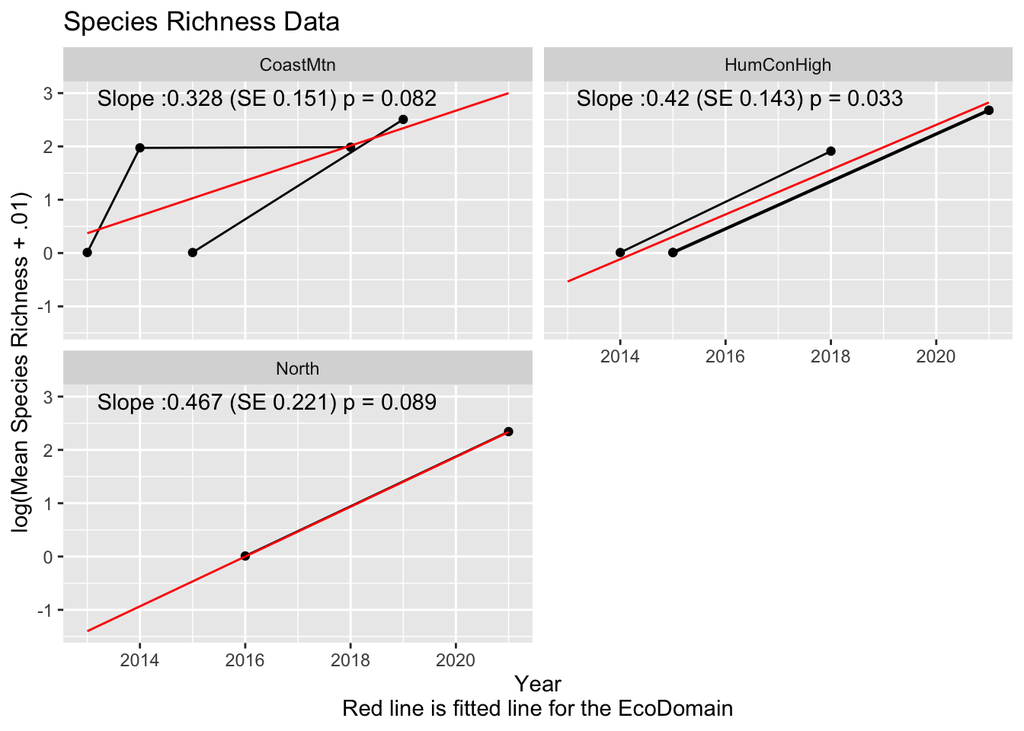

Figure 7: Summary plot of the trend in mean species richness per plot.

### 4.2.7 Estimated variance component

The estimated variance components are shown in Table 8.

Table 8: Estimated variance components

| Component | Interaction | SD |
| --- | --- | --- |
| TRANSECT |  | 0.020 |
| YearF:ECODOMAIN |  | 0.779 |
| STUDY_AREA_NAME | Year | 0.000 |
| STUDY_AREA_NAME |  | 0.000 |
| Residual |  | 0.094 |

The *STUDY_AREA_NAME* and *STUDY_AREA_NAME:Year* represent the variation in the intercepts and slopes among study areas within an EcoDomain. The *TRANSECT* component represents the variation in intercepts among multiple transects within the same STUDY_AREA. The *YearF:ECODOMAIN* components represents the variation in the year specific factors (process error) within the EcoDomains. Finally the *Residual* component represents the left-over, unexplained variation in the data.

Notice in this case, that the variation in the slopes for each STUDY_AREA within the EcoDomains is very close to 0, i.e., the different study areas could all have similar slopes within the EcoDomain. If you examine the individual slopes in each study area (see the individual study area reports), the estimated standard error is quite large indicating the the slopes could be roughly the same across study areas (see Figure 8).

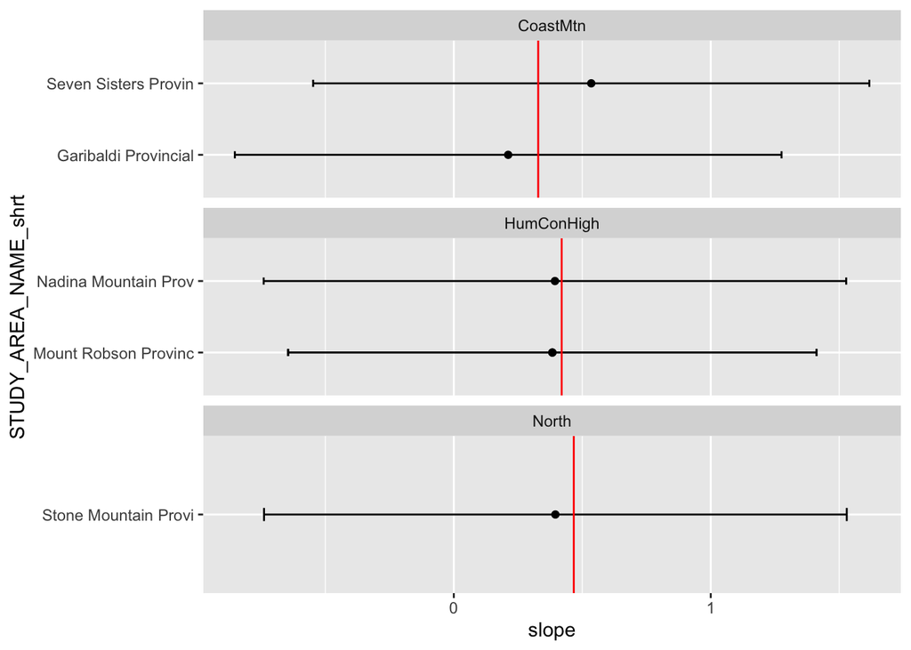

Figure 8: Comparing the individual slopes within each EcoRegion

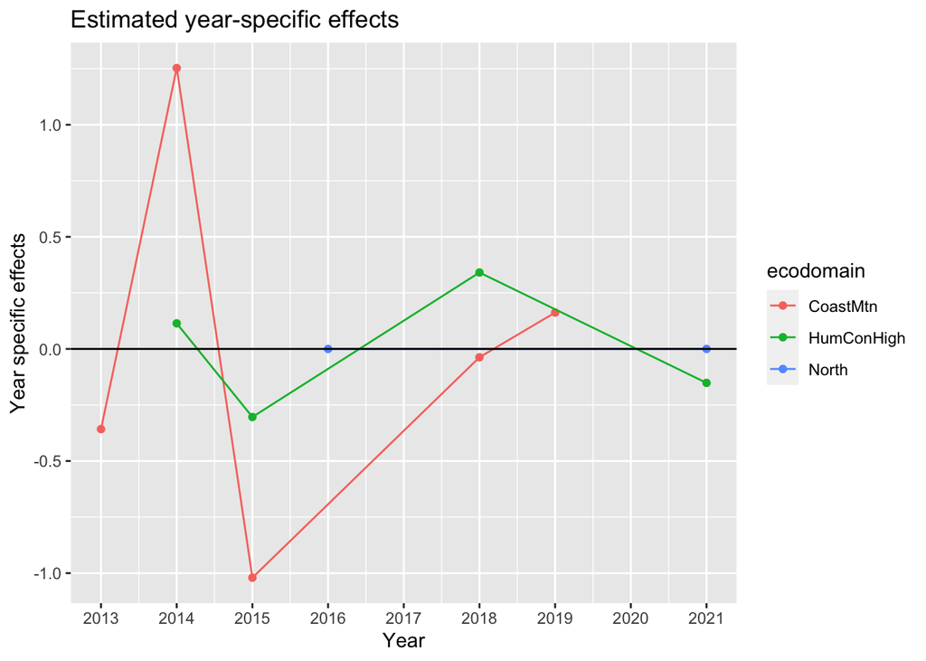

Figure 9: Plot of year specific effects

We see that the year-specific effects can vary across EcoDomains, e.g., the year-specific impact of weather can be different in the different EcoDomains. This is not surprising because B.C. is a large Province!

### 4.2.8 Residual plots

Residual plots are presented in Figure 10.

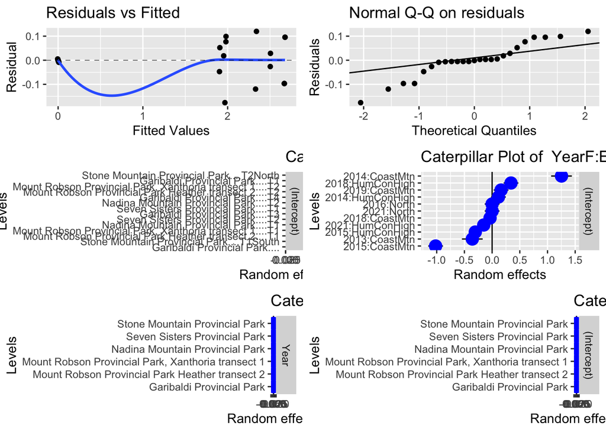

Figure 10: Model fit diagnostic plots from trend in mean transect counts

## 4.3 Diversity

Species richness is one measure of diversity and there are many more such as Simpson’s or Shannon’s measure of diversity. A similar analysis as for species richness can be done on these other measures of diversity, but are no longer recommended because these measures are often insensitive to big changes in diversity and because they do not account for functional similarity among species. For example, the diversity of six dramatically different species of plants is considered to be no more diverse than six related species.

Leinster and Cobbold (2012) showed how different diversity measures all belong to a continuum (called a diversity profile) and how species similarity can be used to augment the standard diversity measures. The diversity profile also has a number of advantages over the traditional measures of diversity as noted by Chao and Jost (2013) and Jost (2013).

The key difficulty with traditional measures of diversity is that there is non-linear relationship between the diversity measure and biological implications. For this reason, it is often useful to think in terms of “effective number of species” (Jost, 2006; Jost 2013). Briefly, the effective number of species is the number of equally abundant species that give rise to a particular diversity index value.

Jost (2013) provides an example of the problems with traditional diversity measures:

> “… suppose you are comparing the diversity of aquatic microorganisms before and after an oil spill. You wouldn’t want to measure that diversity by species richness because even a massive toxic event is sure to leave a few vagrant individuals of each pre-spill species, and species richness doesn’t distinguish between one individual of Species X or a million; the pre- and post-spill species counts might not be very different, even if the pre- and post-spill species frequencies are very different. So if you are a good traditional biologist you might use the popular Gini-Simpson diversity index, which is $1-\sum_i{p_i^2}$ where $p_i$ is a measure of relative abundance for species i. Suppose that the pre-spill Gini-Simpson index is .99 and the post-spill index is .97. If you are a good traditional biologist you would figure out that this drop is statistically significant, but you would conclude that the magnitude of the drop is small. You might even say (very wrongly) that the diversity has dropped by 2%, which sounds like a small drop, nothing to worry about.

Leinster and Cobbold (2012) defined the diversity profile as series of “effective numbers” dependent on an index $q$ (which ranges from 0 to infinity) and a similarity matrix $\bf{Z}$ (whose $(i,j)$ entry measures the similarity of species $i$ and species $j$ from 0 (not similar) to 1 (completely similar)). The diversity profile is computed as:
$$^{q}D^Z(\bf{p})= \left( {\sum {p_i(\bf{Zp})^{q-1}_i}} \right) ^{1/(1-q)}$$
where the vector $\bf{p}$ is the relative abundance of the species present (i.e., excluding species with 0 abundance), and $\bf{Z}$ is the similarity matrix among the vector of species. As shown by Leinster and Cobbold (2012), many of the common diversity indices are special cases of the above. For example, if $q = 0$, the above equation reduces to species richness; if $q = 1$ and $\bf{Z}=\bf{I}$, then the above is related to the Shannon Index; and if $q=2$ and $\bf{Z}=\bf{I}$, then the above is related to the Simpson Index of diversity.

I’ve included a briefing note on the analysis of diversity in an environmental impact assessment case with this material as illustration of the method. For the rest of this section, the diversity measures will be computed assuming a diagonal $\bf{Z}$ matrix, i.e. every species is functionally distinct which is obviously incorrect.

[output not shown]

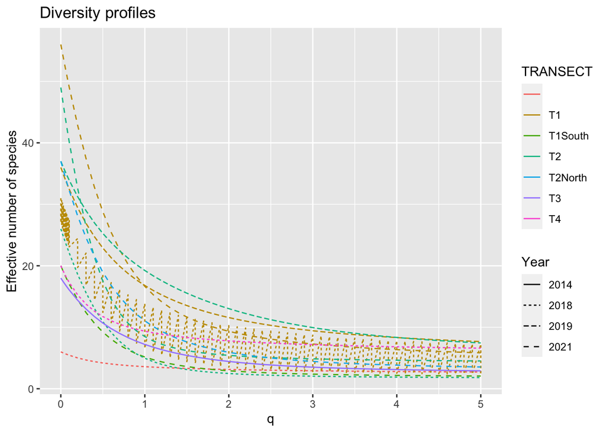

Once the diversity profiles have been computed, the effective number of species for any value of $q$ can be extracted and analyzed in the same way as the analysis for the average species richness.

For example, here are the extracted diversity values for $q = 2$ which is related to the Simpson Index of diversity:

```
 Year TRANSECT q diversity STUDY_AREA_NAME_shrt  ECODOMAIN
 2014       T3 2       4.4 Garibaldi Provincial   CoastMtn
 2018          2       3.1 Garibaldi Provincial   CoastMtn
 2018       T1 2      10.3 Garibaldi Provincial   CoastMtn
 2018       T4 2       7.8 Garibaldi Provincial   CoastMtn
 2021       T1 2       9.3 Mount Robson Provinc HumConHigh
 2021       T2 2       5.4 Mount Robson Provinc HumConHigh
 2021       T1 2       9.3 Mount Robson Provinc HumConHigh
 2021       T2 2       5.4 Mount Robson Provinc HumConHigh
 2018       T1 2       3.5 Nadina Mountain Prov HumConHigh
 2018       T2 2       2.5 Nadina Mountain Prov HumConHigh
 2019       T1 2      11.6 Seven Sisters Provin   CoastMtn
 2019       T2 2      13.0 Seven Sisters Provin   CoastMtn
 2021  T1South 2       2.9 Stone Mountain Provi      North
 2021  T2North 2       5.9 Stone Mountain Provi      North
```

### 4.3.1 Preliminary plot

A summary plot of the mean diversity in each year for each STUDY_AREA and an the trends over time is shown in Figure 11.

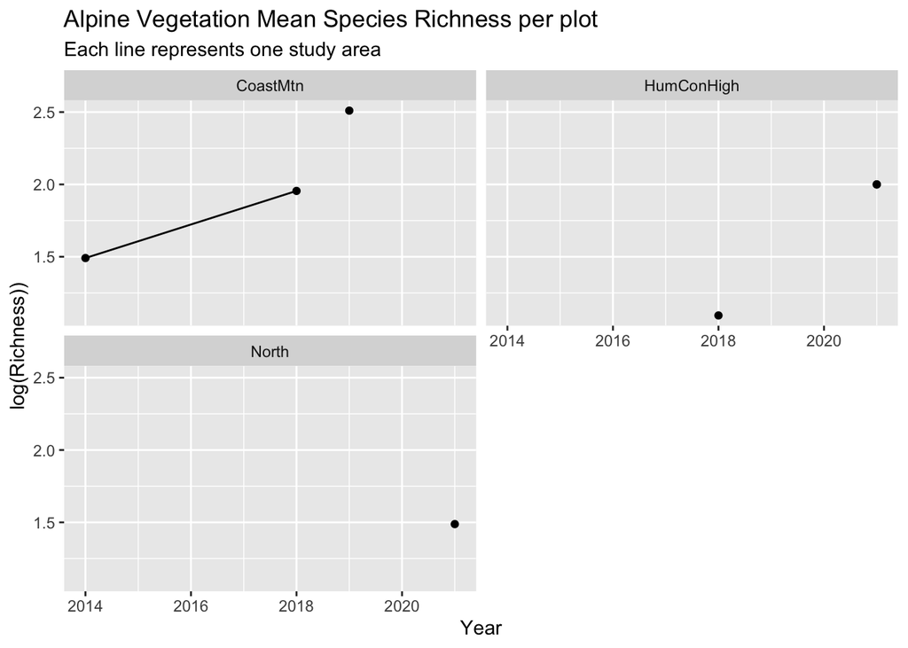

Figure 11: Summary plot of the data. The data is analyzed on the logarithmic scale.

### 4.3.2 Model

A non-parallel slope model is fit allowing for a different average slope (over the multiple STUDY_AREAs) in each EcoDomains (non-parallel slopes). Within each EcoDomain, each STUDY_AREA’s slope is allowed to vary randomly around the average slope for the EcoDomain. Within each STUDY_AREA, each transect is allowed to have a different intercept but common slope. Finally, we allow for year-specific factor within each EcoDomain.

The model, in a short-hand notation is:

$$log(Diversity) \sim \mathit{EcoDomain} + \mathit{Year} + \mathit{EcoDomain}:\mathit{Year}+
\mathit{StudyArea} + \mathit{TransectF(R)} + \mathit{StudyArea}:\mathit{Year(R)} + \mathit{YearF:EcoDomain(R)}$$

where

- $log(Diversity)$ is logarithm of the diversity score (effective number of species) for that transect in that year.
- $\mathit{Year}$ term represents the average (over all EcoDomains) calendar year trend over time.
- $\mathit{EcoDomain}$ term represents a different intercept for each EcoDomain
- $\mathit{EcoDomain}:\mathit{Year}$ term represents the differential average slope for each EcoDomain
- $\mathit{StudyArea}:\mathit{Year(R)}$ term represents the random slopes within each EcoDomain for each study area
- $\mathit{TransectF(R)}$ represents the (random) transect effect;
- $\mathit{YearF:EcoDomain(R)}$ represents the (random) year-specific effects (process error), thare are allowed to vary across EcoDomains.

The The $\mathit{TransectF}$ term allows for the fact that transect-specific conditions may tend to affect the counts on this transect consistently over time. The $\mathit{YearF:EcoDomain}$ term represent the year-specific effects (process error) caused by environmental factors (e.g., a warmer than normal year may lead to more plant growth).

Model fit on the logarithmic scale assume that effects are multiplicative over time, so that the when the actual fit is done on the logarithmic scale, the trends are linear. For example, a trend may assume that there is constant 5% change over time rather than a fixed 1-unit change per year. Some caution is needed if any of the values are 0 as log(0) is not defined. In these cases, a small constant (typically ½ of the smallest positive value in the dataset) is added to all values before the analysis proceeds.

The model was fit using the *lmerTest()* function (Kuznetsova, 2017) in *R* (R Core Team, 2023).

[output not shown]

[output not shown]

[output not shown]

### 4.3.3 Test for no difference in trends among EcoDomains

After the model is fit, the ANOVA tables summarizes the test for no differences in trends among the EcoDomains in Table 9.

Table 9: ANOVA table for testing for differences in trends among EcoDomains

| Source | NumDF | DenDF | p.value |
| --- | --- | --- | --- |
| Year | 1 | 4.9 | p = 0.011 |
| ECODOMAIN | 2 | 4.9 | p = 0.723 |
| Year:ECODOMAIN | 2 | 4.9 | p = 0.853 |

The *Year:ECODOMAIN* term tests the hypothesis that the slopes in all of the EcoDomains are equal. If the p-value is large, then there is no evidence that the slopes among the EcoDomains are different.

### 4.3.4 Estimated slopes

The estimated coefficients from *R* output above do not have a direct interpretation because of the way that *R* codes the design matrix for discrete variables such as the EcoDomain.These coefficients associated with each EcoDomain are the difference in the slopes between the slope for that particular EcoDomain and the reference EcoDomain (typically the EcoDomain that is “first” alphabetically).

The estimated slope for each EcoDomain are estimated using the *emmeans* package (Lenth, 2023) presented in Table 10.

Table 10: Estimated slope in each EcoDomain

| Eco Domain | Slope | SE | df | 95% LCL | 95% UCL | Grouping |
| --- | --- | --- | --- | --- | --- | --- |
| CoastMtn | 0.3285 | 0.1513 | 5.0 | -0.0612 | 0.7181 | 1 |
| HumConHigh | 0.4199 | 0.1427 | 4.9 | 0.0514 | 0.7885 | 1 |
| North | 0.4669 | 0.2213 | 4.9 | -0.1039 | 1.0377 | 1 |

Degrees-of-freedom method: satterthwaite  
Confidence level used: 0.95  
Degrees-of-freedom method: satterthwaite  
P value adjustment: tukey method for comparing a family of 3 estimates  
significance level used: alpha = 0.05  
NOTE: If two or more means share the same grouping symbol, then we cannot show them to be different. But we also did not show them to be the same.

The *Grouping* column indicates if there is evidence of a difference among the slopes across EcoDomains. EcoDomains that contain the same “digit” would indicate no evidence of a difference in the mean slopes among the EcoDomains. This is a summary of the overall p-value for parallelism found in the ANOVA table of p = 0.853. For more information on interpretting the *.group* variable, refer to https://schmidtpaul.github.io/DSFAIR/compactletterdisplay.html.

### 4.3.5 Mean slope over all EcoDomains

The average slope over all EcoDomains (giving each EcoDomain equal weight regardless of the number of study areas in the EcoDomain) shown in Table 11.

Table 11: Estimated mean slope over all EcoDomains

| Mean slope | Slope | SE | df | 95% LCL | 95% UCL | p.value |
| --- | --- | --- | --- | --- | --- | --- |
| overall | 0.4051 | 0.1012 | 4.9 | 0.1440 | 0.6662 | p = 0.011 |

Results are averaged over the levels of: ECODOMAINF  
Degrees-of-freedom method: satterthwaite  
Confidence level used: 0.95

The overall average slope over all EcoDomain is 0.405 (SE 0.101 with a p-value of p = 0.011. This is the same p-value from the ANOVA table for the *Year* term.

The estimated mean slope is interpreted in the same way as the slopes for each EcoDomain.

### 4.3.6 Summary plot

Figure 12 shows a summary plot, along with estimates of the slope, its standard error, and the p-value of the hypothesis of no trend in each EcoDomain.

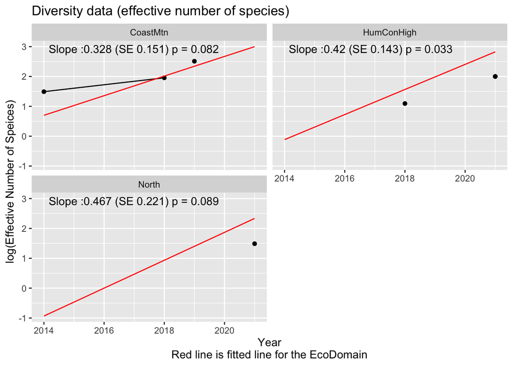

Figure 12: Summary plot of the trend in effective number of species.

### 4.3.7 Estimated variance component

The estimated variance components are shown in Table 12.

Table 12: Estimated variance components

| Component | Interaction | SD |
| --- | --- | --- |
| TRANSECT |  | 0.020 |
| YearF:ECODOMAIN |  | 0.779 |
| STUDY_AREA_NAME | Year | 0.000 |
| STUDY_AREA_NAME |  | 0.000 |
| Residual |  | 0.094 |

The *STUDY_AREA_NAME* and *STUDY_AREA_NAME:Year* represent the variation in the intercepts and slopes among study areas within an EcoDomain. The *TRANSECT* component represents the variation in intercepts among multiple transects within the same STUDY_AREA. The *YearF:ECODOMAIN* components represents the variation in the year specific factors (process error) within the EcoDomains. Finally the *Residual* component represents the left-over, unexplained variation in the data.

[figure not shown]

Figure 13: Comparing the individual slopes within each EcoRegion

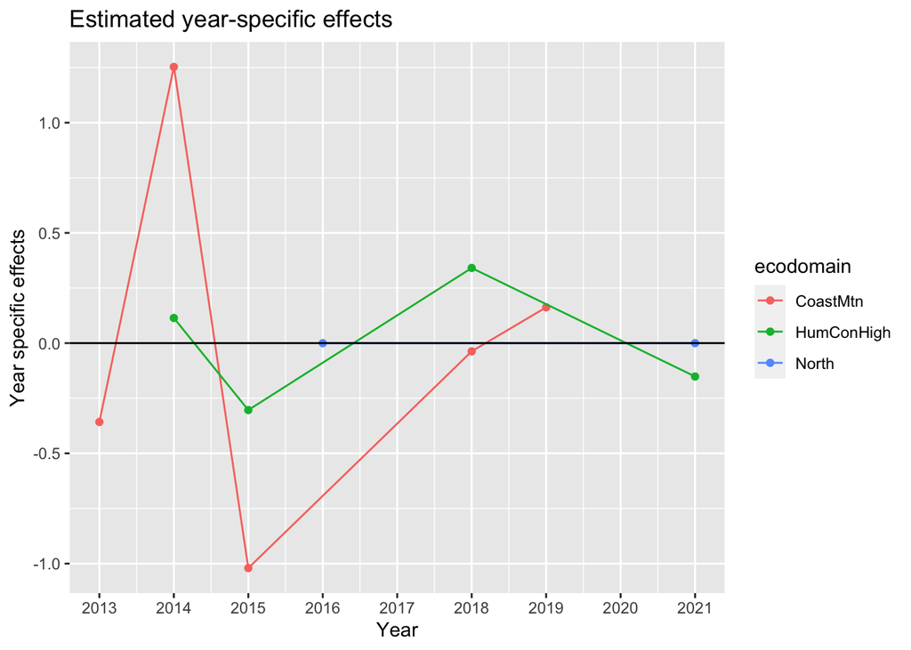

Figure 14: Plot of year specific effects

We see that the year-specific effects can vary across EcoDomains, e.g., the year-specific impact of weather can be different in the different EcoDomains. This is not surprising because B.C. is a large Province!

### 4.3.8 Residual plots

Residual plots are presented in Figure 15.

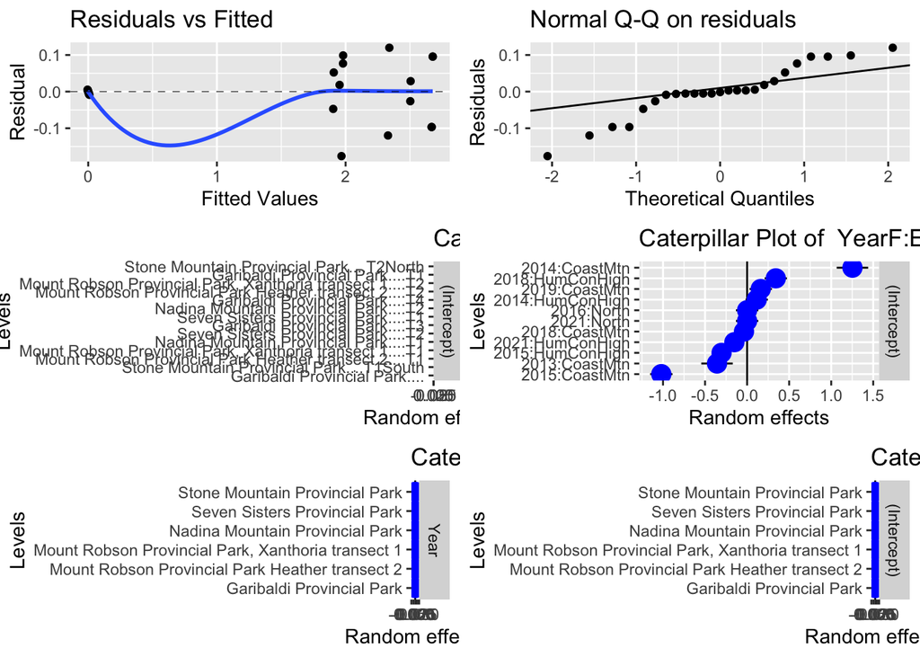

Figure 15: Model fit diagnostic plots from trend in mean transect counts

# 5 Summary

# 6 References

Kuznetsova A, Brockhoff PB, Christensen RHB (2017). “lmerTest Package: Tests in Linear Mixed Effects Models.” Journal of Statistical Software, 82, 1-26. doi:10.18637/jss.v082.i13 https://doi.org/10.18637/jss.v082.i13.

Lenth R (2023). emmeans: Estimated Marginal Means, aka Least-Squares Means. R package version 1.8.4-1, https://CRAN.R-project.org/package=emmeans.